# Geospatial Data in R

Sarah Strochak

5/10/2019

## Geospatial data in R

Geospatial analysis is one of the fastest growing areas of R. In particular. special features provide a tidy way to analyze and visualize spatial data.

### Why map in R?

Reproducabilty is key. Not only does mapping in R allow you to easily make many iterations of the same map, writing code provides a roadmap for others (and future you!) to figure out what was done.

There are several R packages that make it even more convenient to map in R:

- `sf`
- `tigris`
- `urbnmapr`
- `ggplot2`

### Some great resources:

- Robin Lovelace, [Geocomputation with R](https://geocompr.robinlovelace.net/index.html)
- All of the vignettes for the [`sf` package](https://cran.r-project.org/web/packages/sf/sf.pdf)
- The Urban Institute [mapping guide](https://ui-research.github.io/r-at-urban/mapping.html) (major updates coming soon!)

## Reading in data

```r
library(tidyverse)
library(sf)
library(urbnthemes)
library(urbnmapr)
library(tigris)
```

### Reading in shapefiles

`st_read` allows you to read in shapefiles as an `sf` object. Once read in, you can reproject. When mapping and doing geospatial operations, it is important that all features are in the same projection.

```r
list.files("shapefiles")
```

```
## [1] "2015 MSA Boundary.cpg"     "2015 MSA Boundary.dbf"
## [3] "2015 MSA Boundary.prj"     "2015 MSA Boundary.sbn"
## [5] "2015 MSA Boundary.sbx"     "2015 MSA Boundary.shp"
## [7] "2015 MSA Boundary.shp.xml" "2015 MSA Boundary.shx"
```

```r
msa_boundary <- st_read(dsn = "shapefiles",
                        layer = "2015 MSA Boundary")
msa_boundary <- st_transform(msa_boundary, crs = 4326)


st_geometry(msa_boundary)
```

```
## Geometry set for 24 features
## geometry type:  MULTIPOLYGON
## dimension:      XY
## bbox:           xmin: -78.38668 ymin: 37.99093 xmax: -76.32191 ymax: 39.72004
## epsg (SRID):    4326
## proj4string:    +proj=longlat +datum=WGS84 +no_defs
## First 5 geometries:
```

```
## MULTIPOLYGON (((-77.29541 38.50924, -77.29536 3...
```

```
## MULTIPOLYGON (((-77.04802 38.84126, -77.04775 3...
```

```
## MULTIPOLYGON (((-77.93545 38.69585, -77.93551 3...
```

```
## MULTIPOLYGON (((-77.00244 38.96567, -77.0015 38...
```

```
## MULTIPOLYGON (((-77.17228 38.89324, -77.17209 3...
```

### Converting dataframes to `sf`

If you have a dataframe that contains latitude and longitude, you can easily convert your data to a `sf` ponit dataframe. It is important to know what coordinate reference system the coordinates are based on, so you can properly assign the CRS or projection. Note that `st_set_crs` is used to assign a projection; `st_transform` is used to alter a projection that already exists.

```r
banks <- read_csv("data/fdic-sod-dc_2017.csv")

banks_sf <- banks %>%
  filter(!is.na(sims_longitude), !is.na(sims_latitude)) %>%
  st_as_sf(coords = c("sims_longitude", "sims_latitude")) %>%
  st_set_crs(4326)
```

### Packages with data

`tigris` allows you to pull Census boundaries- states, tracts, CBSAs- even roads and military bases.

```r
options(tigris_class = "sf")

dc_tracts <- tracts(state = "DC", cb = TRUE, year = 2010) %>%
  st_transform(crs = 4326)
```

`urbnmapr` (sf support coming very, very soon) has states and counties with Alaska and Hawaii included, for making state and county maps- or can be used to pull data for individual states.

```r
dc <- get_urbn_map(map = "states", sf = TRUE) %>%
  filter(state_fips == "11") %>%
  st_transform(crs = 4326)
```

## Mapping

`geom_sf` from `ggplot2` allows you to map point, line, polygon, and multipolygon data. The syntax follows that of other `geom_*` functions- provide a data set and a set of aesthetics. If you are using an `sf` object with the coordinates saved in a column called `geometry`, you do not need to indicate that in the `aes()` call- this is the default.

You can layer geoms on top of each other; the they wil appear bottom to top.

[figure not shown]

```r
ggplot() +
  geom_sf(msa_boundary, mapping = aes(),
          fill = "grey") +
  geom_sf(banks_sf, mapping = aes(), alpha = .2, fill = "#1696d2") +
  theme_urbn_map() +
  coord_sf(datum = NA) +
  labs(title = "FDIC Insured Bank Branches in the Washignton, DC MSA")
```

For examples of choropleth maps, see the [`urbnmapr` vignette.](https://github.com/UrbanInstitute/urbnmapr)

## Clipping

`st_crop` will crop your data to the bouding box of another spatial data set.

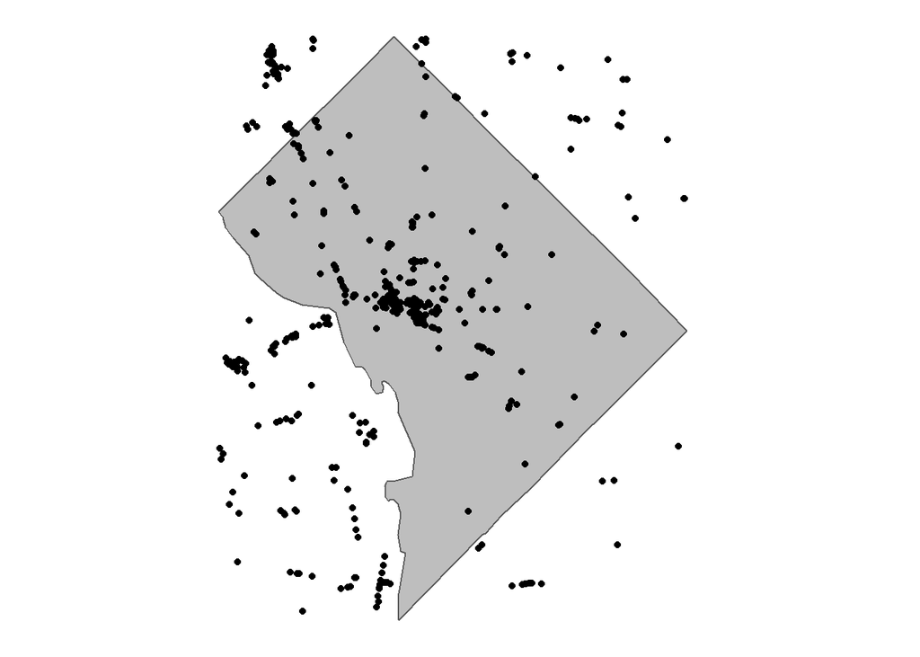

```r
banks_crop <- st_crop(banks_sf, dc)

ggplot() +
  geom_sf(dc, mapping = aes(),
          fill = "grey") +
  geom_sf(banks_crop, mapping = aes()) +
  theme_urbn_map() +
  coord_sf(datum = NA)
```

`st_intersection` will provide an exact clip.

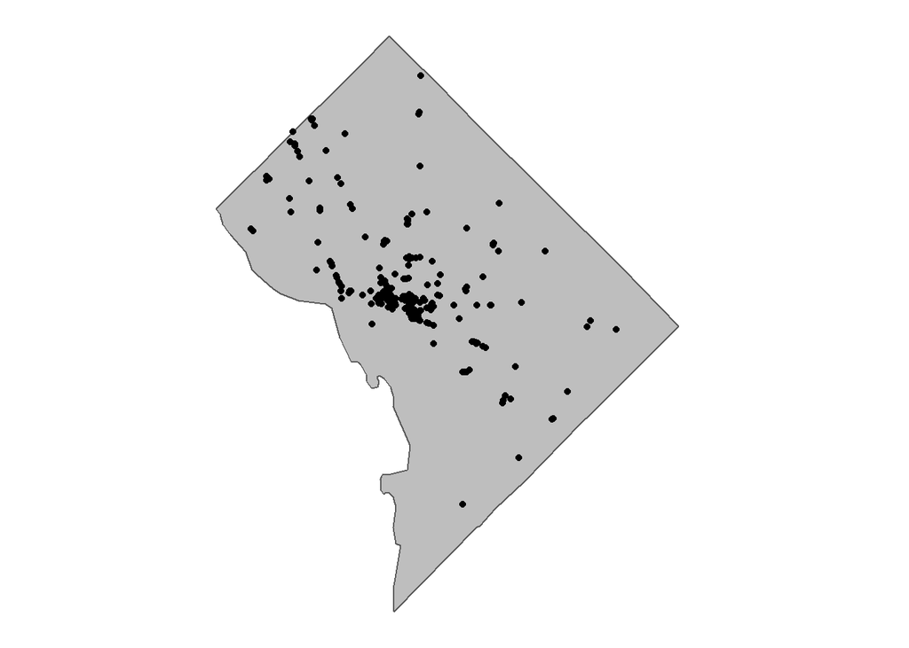

```r
banks_int <- st_intersection(banks_sf, dc)

ggplot() +
  geom_sf(dc, mapping = aes(),
          fill = "grey") +
  geom_sf(banks_int, mapping = aes()) +
  theme_urbn_map() +
  coord_sf(datum = NA)
```

## Spatial joins

Instead of joining on an identifier variable, you can join datasets on geometry.

Say, for instance, you want to figure out which census tracts in DC have the most FDIC-insured bank branches. The function `st_join` has many different options to equate geometries. The [`sf` cheatsheet](https://github.com/rstudio/cheatsheets/raw/master/sf.pdf) is a great resource for remembering and determining which function to use.

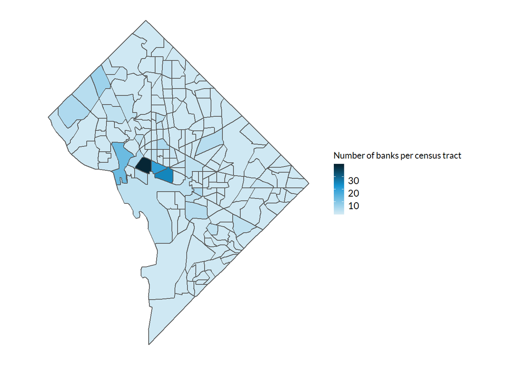

```r
banks_tracts <- st_join(dc_tracts, banks_int, join = st_intersects)

banks_tracts %>%
  group_by(GEO_ID) %>%
  count() %>%
  ggplot() +
  geom_sf(mapping = aes(fill = n)) +
  scale_fill_gradientn() +
  theme_urbn_map() +
  coord_sf(datum = NA) +
  labs(fill = "Number of banks per census tract")
```

## Buffers

The function `st_buffer` can be used to create buffers around geometries. It is important to reproject your data out of long/lat to calculate accurate buffers.

Here, I project the bank coordinates into Marlyand State plane in feet in order to calculate a half mile buffer. `library(units)` is helpful for setting and converting between units.

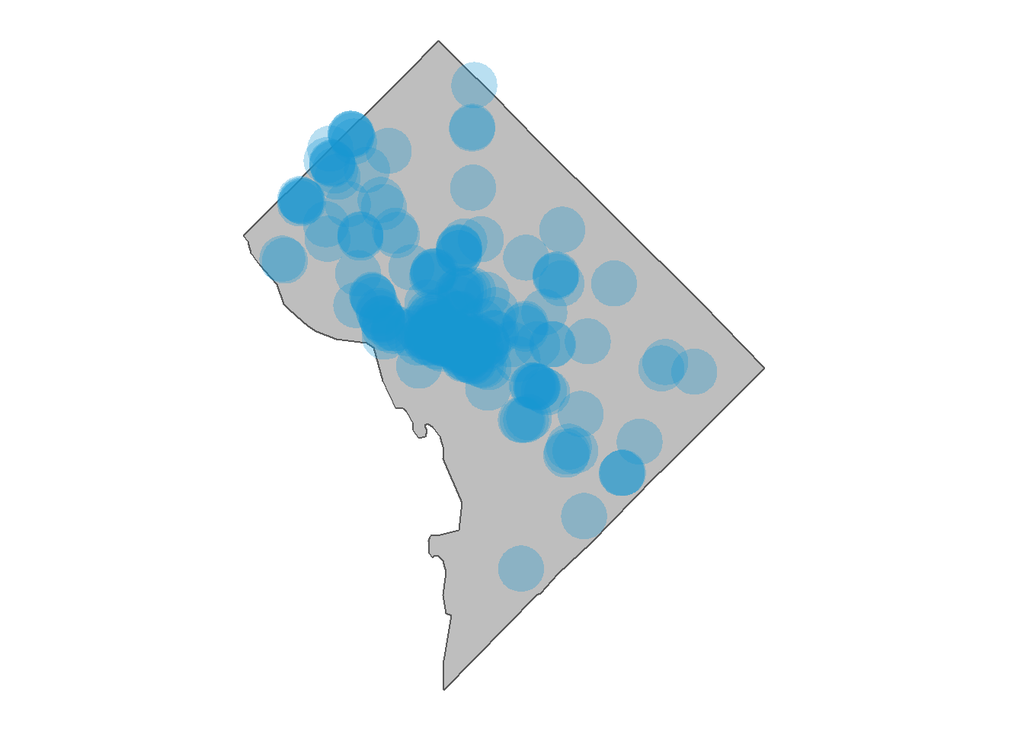

```r
banks_proj <- st_transform(banks_int, crs = 2248)

banks_buffer <- st_buffer(banks_proj, units::set_units(.5, mi) %>% units::set_units(ft)) %>%
  st_transform(crs = 4326)

ggplot() +
  geom_sf(dc, mapping = aes(),
          fill = "grey") +
  geom_sf(banks_buffer, mapping = aes(),
          fill = "#1696d2", alpha = .3, color = NA) +
  theme_urbn_map() +
  coord_sf(datum = NA)
```